# STAT 413/613 HW 1

# 15

```r
# THe top 5 and Bottom 5

C_score %>%
  select(ICLEVEL, INSTNM, MN_EARN_WNE_P10, GRAD_DEBT_MDN) %>%
  filter(!is.na(MN_EARN_WNE_P10),
         !is.na(GRAD_DEBT_MDN),
         ICLEVEL==1) %>%
  summarise(ICLEVEL, INSTNM, Ratio=MN_EARN_WNE_P10/GRAD_DEBT_MDN) %>%
  arrange(-Ratio) %>%
  head(n=5)
```

```
## # A tibble: 5 x 3
##   ICLEVEL INSTNM                                    Ratio
##     <dbl> <chr>                                     <dbl>
## 1       1 SUNY Downstate Health Sciences University  13.6
## 2       1 Stanford University                        12.5
## 3       1 Massachusetts Institute of Technology      12.3
## 4       1 California Institute of Technology         12.2
## 5       1 Princeton University                       11.8
```

```r
C_score %>%
  select(ICLEVEL, INSTNM, MN_EARN_WNE_P10, GRAD_DEBT_MDN) %>%
  filter(!is.na(MN_EARN_WNE_P10),
         !is.na(GRAD_DEBT_MDN),
         ICLEVEL==1) %>%
  summarise(ICLEVEL, INSTNM, Ratio=MN_EARN_WNE_P10/GRAD_DEBT_MDN) %>%
  arrange(-Ratio) %>%
  tail(n=5)
```

```
## # A tibble: 5 x 3
##   ICLEVEL INSTNM                                          Ratio
##     <dbl> <chr>                                           <dbl>
## 1       1 Southwest University of Visual Arts-Tucson      0.705
## 2       1 Southwest University of Visual Arts-Albuquerque 0.705
## 3       1 Benedict College                                0.682
## 4       1 Messenger College                               0.648
## 5       1 Martin University                               0.612
```

## 15.1

```r
# AU ROI

C_score %>%
  select(ICLEVEL, INSTNM, MN_EARN_WNE_P10, GRAD_DEBT_MDN) %>%
  filter(!is.na(MN_EARN_WNE_P10),
         !is.na(GRAD_DEBT_MDN),
         ICLEVEL==1) %>%
  summarise(ICLEVEL, INSTNM, ROI=MN_EARN_WNE_P10/GRAD_DEBT_MDN) %>%
  filter(INSTNM=="American University")
```

```
## # A tibble: 1 x 3
##   ICLEVEL INSTNM                ROI
##     <dbl> <chr>               <dbl>
## 1       1 American University  2.91
```

# 16 World Bank Data

The World Bank provides loans to countries with the goal of reducing poverty. The dataframes in the data folder were taken from the public data repositories of the World Bank.

- country.csv: Contains information on the countries in the data set.
  - The variables are:
  - `Country_Code`: A three-letter code for the country. Note not all rows are countries; some are regions.
  - `Region`: The region of the country.
  - `IncomeGroup`: Either `"High income"`, `"Upper middle income"`, `"Lower middle income"`, or `"Low income"`.
  - `TableName`: The full name of the country.
- fertility.csv: Contains the fertility rate information for each country for each year.
  - For the variables `1960` to `2017`, the values in the cells represent the fertility rate in total births per woman for that year.
  - Total fertility rate represents the number of children that would be born to a woman if she were to live to the end of her childbearing years and bear children in accordance with age-specific fertility rates of the specified year.
- life_exp.csv: Contains the life expectancy information for each country for each year.
  - For the variables `1960` to `2017`, the values in the cells represent life expectancy at birth in years for the given year.
  - Life expectancy at birth indicates the number of years a newborn infant would live if prevailing patterns of mortality at the time of its birth were to stay the same throughout its life.
- population.csv: Contains the population information for each country.
  - For the variables `1960` to `2017`, the values in the cells represent the total population in number of people for the given year.
  - Total population is based on the de facto definition of population, which counts all residents regardless of legal status or citizenship. The values shown are midyear estimates.
1. Use relative paths and a readr function to load these files into four tibbles.

# 17 Import of the data

```r
Fert <- read_csv(file = "./../data/fertility.csv")
Life <- read_csv(file = "./../data/life_exp.csv")
Pop <- read_csv(file = "./../data/population.csv")
Country <- read_csv(file = "./../data/country.csv")
```

2. These data are messy. The observational units in `fert`, `life`, and `pop` are locations in space-time (e.g. Aruba in 2017). Recall tidy data should have one observational unit per row.

# 18 2.1.

-Use dplyr 1.0 functions to tidy these three tibbles and save the updated data frames. -Use an approach where the tidying function also ensures the variable for `year` is a numeric.

```r
Fert_updated <-  Fert %>%
  pivot_longer(cols = 3:61,
               names_to = "Year",
               values_to = "fert_rate",
               names_transform = list(Year = as.numeric)) ->
  Fert_updated


Life_updated <-  Life %>%
  pivot_longer(cols = 3:61,
               names_to = "Year",
               values_to = "life_exp",
               names_transform = list(Year = as.numeric)) ->
  Life_updated


Pop_updated <-  Pop %>%
  pivot_longer(cols = 3:61,
               names_to = "Year",
               values_to = "population",
               names_transform = list(Year = as.numeric)) ->
  Pop_updated
```

3. Use dplyr functions to combine the three tibbles into one and save to a new tibble which includes the fertility rate, population, and life expectancy in each year as well as the region for each country.

# 19 solution.

```r
Full_data <- Fert_updated %>%

left_join(Life_updated, by = c("Country Name", "Country Code", "Year")) %>%
left_join(Pop_updated, by = c("Country Name", "Country Code", "Year"))
```

# 20 join country by Regionn

```r
Full_data <- Country %>%
  select(`Country Code`, Region) %>%
  left_join(Full_data, by = "Country Code")
```

4. Make a scatter plot of fertility rate vs life expectancy, color-coding by region and annotating size by the population.
- Include only the years 1960, 1970, 1980, 1990, 2000, and 2010.
- Facet by these years.
- Your final plot should look like this (Each element of the formatting is graded):
- **Interpret the plot in one sentence**.

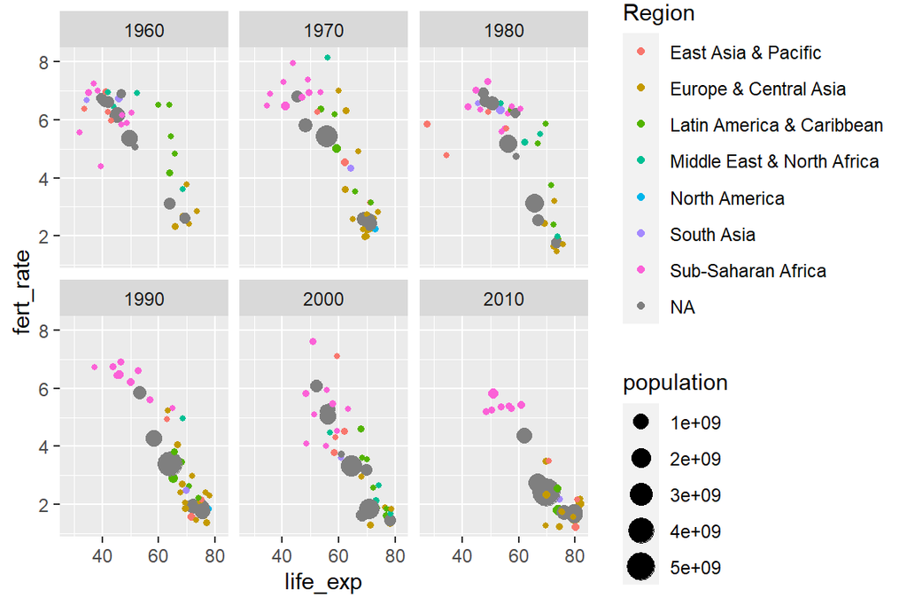

```r
Full_data %>%
  filter(Year== c( 1960, 1970, 1980, 1990, 2000, 2010)) %>%
  ggplot(aes(x = life_exp, y = fert_rate, size = population, color = Region)) +
  geom_point() +
  facet_wrap(vars(Year))
```

5. Calculate the total population for each region for each year.
- Exclude 2018.
- Make a line plot of year versus total population, color-coding by region and using a log scale.
- Your final plot should look like this:
- **Interpret the plot in one sentence to identify the fastest growing regions**.

```r
Full_data %>%

  filter(Year != 2018, na.rm = TRUE) %>%

  group_by(Region, Year) %>%

  summarise(tot_pop = sum(population, na.rm = TRUE)) ->

   Full_new
```

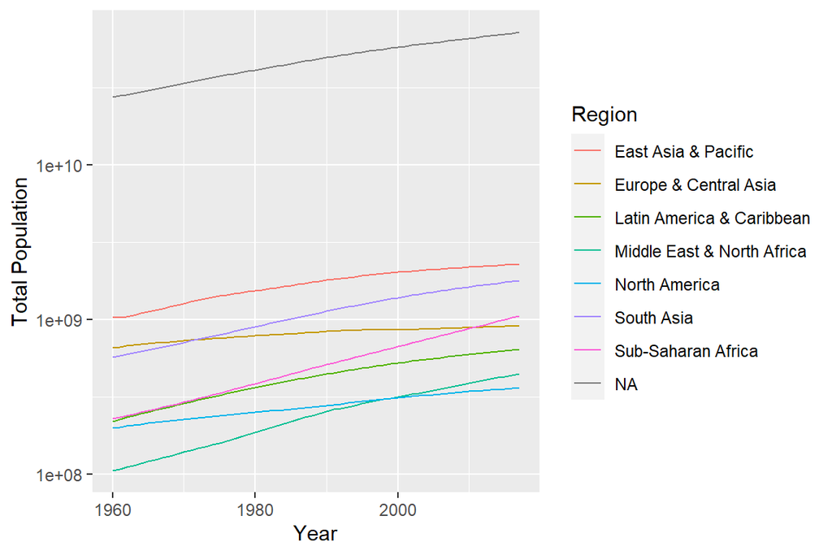

```r
Full_new %>%
  ggplot(mapping = aes(x = Year, y = tot_pop, color = Region)) +
  geom_line() +
  scale_y_log10() +
  xlab("Year") +
  ylab("Total Population")
```

6. Make a bar plot of population vs region for the year 2010.
- Order the bars on the $y$-axis in **decreasing** order of population.
- Your final plot should look like this:

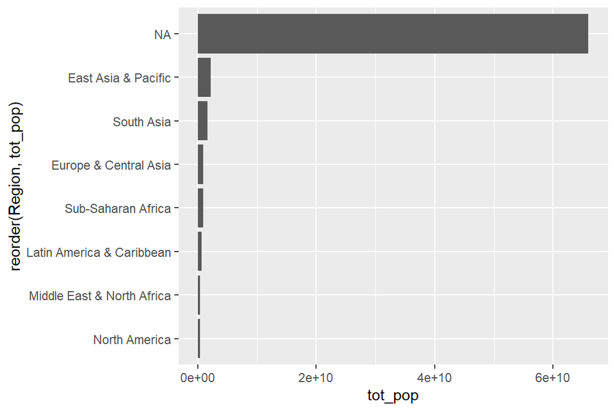

```r
Full_new %>%
  filter(Year==2010) %>%
  ggplot(aes(x = reorder(Region, tot_pop), y = tot_pop)) +
  geom_col() +
  coord_flip()
```